# Predicting houses prices

Mo’men Mohamed

April 19, 2019

the aim of this analysis to use weighted regression to predict the houses prices

plz feel free to contact me for any advice or recommendations: vet.m.mohamed@gmail.com

find the data [here](https://www.kaggle.com/harlfoxem/housesalesprediction)

firstly lets load the libraries we are going to use

```r
library(tidyverse)
library(caret)
library(mice)
library(car)
library(lm.beta)
library(knitr)
```

Next lets import the data

```r
houses<-read_csv(file = "./data sets/kc_house_data.csv",col_types = "cTninnnifffinnddf??nn")

head(houses)%>%kable("markdown")
```

| id | date | price | bedrooms | bathrooms | sqft_living | sqft_lot | floors | waterfront | view | condition | grade | sqft_above | sqft_basement | yr_built | yr_renovated | zipcode | lat | long | sqft_living15 | sqft_lot15 |
| --- | --- | --- | --- | --- | --- | --- | --- | --- | --- | --- | --- | --- | --- | --- | --- | --- | --- | --- | --- | --- |
| 7129300520 | 2014-10-13 | 221900 | 3 | 1.00 | 1180 | 5650 | 1 | 0 | 0 | 3 | 7 | 1180 | 0 | 1955 | 0 | 98178 | 47.5112 | -122.257 | 1340 | 5650 |
| 6414100192 | 2014-12-09 | 538000 | 3 | 2.25 | 2570 | 7242 | 2 | 0 | 0 | 3 | 7 | 2170 | 400 | 1951 | 1991 | 98125 | 47.7210 | -122.319 | 1690 | 7639 |
| 5631500400 | 2015-02-25 | 180000 | 2 | 1.00 | 770 | 10000 | 1 | 0 | 0 | 3 | 6 | 770 | 0 | 1933 | 0 | 98028 | 47.7379 | -122.233 | 2720 | 8062 |
| 2487200875 | 2014-12-09 | 604000 | 4 | 3.00 | 1960 | 5000 | 1 | 0 | 0 | 5 | 7 | 1050 | 910 | 1965 | 0 | 98136 | 47.5208 | -122.393 | 1360 | 5000 |
| 1954400510 | 2015-02-18 | 510000 | 3 | 2.00 | 1680 | 8080 | 1 | 0 | 0 | 3 | 8 | 1680 | 0 | 1987 | 0 | 98074 | 47.6168 | -122.045 | 1800 | 7503 |
| 7237550310 | 2014-05-12 | 1225000 | 4 | 4.50 | 5420 | 101930 | 1 | 0 | 0 | 3 | 11 | 3890 | 1530 | 2001 | 0 | 98053 | 47.6561 | -122.005 | 4760 | 101930 |

checking the structure of the data

```r
str(houses)
```

```
## Classes 'spec_tbl_df', 'tbl_df', 'tbl' and 'data.frame': 21613 obs. of  21 variables:
##  $ id           : chr  "7129300520" "6414100192" "5631500400" "2487200875" ...
##  $ date         : POSIXct, format: "2014-10-13" "2014-12-09" ...
##  $ price        : num  221900 538000 180000 604000 510000 ...
##  $ bedrooms     : int  3 3 2 4 3 4 3 3 3 3 ...
##  $ bathrooms    : num  1 2.25 1 3 2 4.5 2.25 1.5 1 2.5 ...
##  $ sqft_living  : num  1180 2570 770 1960 1680 ...
##  $ sqft_lot     : num  5650 7242 10000 5000 8080 ...
##  $ floors       : int  1 2 1 1 1 1 2 1 1 2 ...
##  $ waterfront   : Factor w/ 2 levels "0","1": 1 1 1 1 1 1 1 1 1 1 ...
##  $ view         : Factor w/ 5 levels "0","3","4","2",..: 1 1 1 1 1 1 1 1 1 1 ...
##  $ condition    : Factor w/ 5 levels "3","5","4","1",..: 1 1 1 2 1 1 1 1 1 1 ...
##  $ grade        : int  7 7 6 7 8 11 7 7 7 7 ...
##  $ sqft_above   : num  1180 2170 770 1050 1680 ...
##  $ sqft_basement: num  0 400 0 910 0 1530 0 0 730 0 ...
##  $ yr_built     : num  1955 1951 1933 1965 1987 ...
##  $ yr_renovated : num  0 1991 0 0 0 ...
##  $ zipcode      : Factor w/ 70 levels "98178","98125",..: 1 2 3 4 5 6 7 8 9 10 ...
##  $ lat          : num  47.5 47.7 47.7 47.5 47.6 ...
##  $ long         : num  -122 -122 -122 -122 -122 ...
##  $ sqft_living15: num  1340 1690 2720 1360 1800 ...
##  $ sqft_lot15   : num  5650 7639 8062 5000 7503 ...
##  - attr(*, "problems")=Classes 'tbl_df', 'tbl' and 'data.frame': 2079 obs. of  5 variables:
##   ..$ row     : int  13 15 18 26 28 33 34 36 55 66 ...
##   ..$ col     : chr  "floors" "floors" "floors" "floors" ...
##   ..$ expected: chr  "no trailing characters" "no trailing characters" "no trailing characters" "no trailing characters" ...
##   ..$ actual  : chr  ".5" ".5" ".5" ".5" ...
##   ..$ file    : chr  "'./data sets/kc_house_data.csv'" "'./data sets/kc_house_data.csv'" "'./data sets/kc_house_data.csv'" "'./data sets/kc_house_data.csv'" ...
##  - attr(*, "spec")=
##   .. cols(
##   ..   id = col_character(),
##   ..   date = col_datetime(format = ""),
##   ..   price = col_number(),
##   ..   bedrooms = col_integer(),
##   ..   bathrooms = col_number(),
##   ..   sqft_living = col_number(),
##   ..   sqft_lot = col_number(),
##   ..   floors = col_integer(),
##   ..   waterfront = col_factor(levels = NULL, ordered = FALSE, include_na = FALSE),
##   ..   view = col_factor(levels = NULL, ordered = FALSE, include_na = FALSE),
##   ..   condition = col_factor(levels = NULL, ordered = FALSE, include_na = FALSE),
##   ..   grade = col_integer(),
##   ..   sqft_above = col_number(),
##   ..   sqft_basement = col_number(),
##   ..   yr_built = col_double(),
##   ..   yr_renovated = col_double(),
##   ..   zipcode = col_factor(levels = NULL, ordered = FALSE, include_na = FALSE),
##   ..   lat = col_double(),
##   ..   long = col_double(),
##   ..   sqft_living15 = col_number(),
##   ..   sqft_lot15 = col_number()
##   .. )
```

removing id lat long date

```r
houses<-houses%>%select(-c(id,date,lat,long))
```

need to check the condition if it need to be ordered

```r
unique(houses$condition)
```

```
## [1] 3 5 4 1 2
## Levels: 3 5 4 1 2
```

i think that is preferable if it is ordered

```r
houses<-houses%>%mutate(condition=factor(condition,levels = c("1","2","3","4","5"),labels = c("1","2","3","4","5"),ordered = T))
```

checking the structure again

```r
str(houses)
```

```
## Classes 'spec_tbl_df', 'tbl_df', 'tbl' and 'data.frame': 21613 obs. of  17 variables:
##  $ price        : num  221900 538000 180000 604000 510000 ...
##  $ bedrooms     : int  3 3 2 4 3 4 3 3 3 3 ...
##  $ bathrooms    : num  1 2.25 1 3 2 4.5 2.25 1.5 1 2.5 ...
##  $ sqft_living  : num  1180 2570 770 1960 1680 ...
##  $ sqft_lot     : num  5650 7242 10000 5000 8080 ...
##  $ floors       : int  1 2 1 1 1 1 2 1 1 2 ...
##  $ waterfront   : Factor w/ 2 levels "0","1": 1 1 1 1 1 1 1 1 1 1 ...
##  $ view         : Factor w/ 5 levels "0","3","4","2",..: 1 1 1 1 1 1 1 1 1 1 ...
##  $ condition    : Ord.factor w/ 5 levels "1"<"2"<"3"<"4"<..: 3 3 3 5 3 3 3 3 3 3 ...
##  $ grade        : int  7 7 6 7 8 11 7 7 7 7 ...
##  $ sqft_above   : num  1180 2170 770 1050 1680 ...
##  $ sqft_basement: num  0 400 0 910 0 1530 0 0 730 0 ...
##  $ yr_built     : num  1955 1951 1933 1965 1987 ...
##  $ yr_renovated : num  0 1991 0 0 0 ...
##  $ zipcode      : Factor w/ 70 levels "98178","98125",..: 1 2 3 4 5 6 7 8 9 10 ...
##  $ sqft_living15: num  1340 1690 2720 1360 1800 ...
##  $ sqft_lot15   : num  5650 7639 8062 5000 7503 ...
```

now we want to test some assumption starting with is the missing values , what about it ?

```r
summary(houses)
```

```
##      price            bedrooms        bathrooms      sqft_living
##  Min.   :  75000   Min.   : 0.000   Min.   :0.000   Min.   :  290
##  1st Qu.: 321950   1st Qu.: 3.000   1st Qu.:1.750   1st Qu.: 1427
##  Median : 450000   Median : 3.000   Median :2.250   Median : 1910
##  Mean   : 540088   Mean   : 3.371   Mean   :2.115   Mean   : 2080
##  3rd Qu.: 645000   3rd Qu.: 4.000   3rd Qu.:2.500   3rd Qu.: 2550
##  Max.   :7700000   Max.   :33.000   Max.   :8.000   Max.   :13540
##
##     sqft_lot           floors      waterfront view      condition
##  Min.   :    520   Min.   :1.000   0:21450    0:19489   1:   30
##  1st Qu.:   5040   1st Qu.:1.000   1:  163    3:  510   2:  172
##  Median :   7618   Median :1.000              4:  319   3:14031
##  Mean   :  15107   Mean   :1.485              2:  963   4: 5679
##  3rd Qu.:  10688   3rd Qu.:2.000              1:  332   5: 1701
##  Max.   :1651359   Max.   :3.000
##                    NA's   :2079
##      grade          sqft_above   sqft_basement       yr_built
##  Min.   : 1.000   Min.   : 290   Min.   :   0.0   Min.   :1900
##  1st Qu.: 7.000   1st Qu.:1190   1st Qu.:   0.0   1st Qu.:1951
##  Median : 7.000   Median :1560   Median :   0.0   Median :1975
##  Mean   : 7.657   Mean   :1788   Mean   : 291.5   Mean   :1971
##  3rd Qu.: 8.000   3rd Qu.:2210   3rd Qu.: 560.0   3rd Qu.:1997
##  Max.   :13.000   Max.   :9410   Max.   :4820.0   Max.   :2015
##
##   yr_renovated       zipcode      sqft_living15    sqft_lot15
##  Min.   :   0.0   98103  :  602   Min.   : 399   Min.   :   651
##  1st Qu.:   0.0   98038  :  590   1st Qu.:1490   1st Qu.:  5100
##  Median :   0.0   98115  :  583   Median :1840   Median :  7620
##  Mean   :  84.4   98052  :  574   Mean   :1987   Mean   : 12768
##  3rd Qu.:   0.0   98117  :  553   3rd Qu.:2360   3rd Qu.: 10083
##  Max.   :2015.0   98042  :  548   Max.   :6210   Max.   :871200
##                   (Other):18163
```

we have a problem only with floor

lets check the percent of missing

```r
(sum(is.na(houses$floors))/nrow(houses)
)*100
```

```
## [1] 9.619211
```

only 10% of missing values , so i will impute it using multiple imputation method

first i want to extract the numeric variables

```r
num<-houses%>%select(price,bedrooms,bathrooms,sqft_living,sqft_lot,floors,sqft_above,sqft_living15,sqft_lot15)%>%data.frame()

set.seed(3215)

imp<-mice(data = num)
impnum<-complete(imp)%>%data.frame()

houses<-houses%>%mutate(floors=impnum$floors,
                        floors=as.integer(floors))
```

check again for missing

```r
(sum(is.na(houses$floors))/nrow(houses)
)*100
```

```
## [1] 0
```

great

now lets run regular regression to test the assumption

```r
fit<-houses%>%with(lm(price~.,data=houses))
summary(fit)
```

```
##
## Call:
## lm(formula = price ~ ., data = houses)
##
## Residuals:
##      Min       1Q   Median       3Q      Max
## -1238733   -70188     -618    62402  4415643
##
## Coefficients: (1 not defined because of singularities)
##                 Estimate Std. Error t value Pr(>|t|)
## (Intercept)    9.143e+05  1.250e+05   7.316 2.64e-13 ***
## bedrooms      -2.733e+04  1.528e+03 -17.887  < 2e-16 ***
## bathrooms      2.559e+04  2.647e+03   9.669  < 2e-16 ***
## sqft_living    1.272e+02  3.547e+00  35.857  < 2e-16 ***
## sqft_lot       2.433e-01  3.833e-02   6.347 2.23e-10 ***
## floors        -4.887e+04  3.092e+03 -15.807  < 2e-16 ***
## waterfront1    5.634e+05  1.603e+04  35.149  < 2e-16 ***
## view3          1.529e+05  7.617e+03  20.070  < 2e-16 ***
## view4          3.373e+05  1.167e+04  28.913  < 2e-16 ***
## view2          6.829e+04  5.559e+03  12.284  < 2e-16 ***
## view1          7.658e+04  9.099e+03   8.416  < 2e-16 ***
## condition.L    6.642e+04  1.923e+04   3.453 0.000555 ***
## condition.Q    3.217e+02  1.626e+04   0.020 0.984212
## condition.C    3.137e+04  1.223e+04   2.564 0.010345 *
## condition^4   -1.478e+04  7.047e+03  -2.098 0.035950 *
## grade          5.754e+04  1.814e+03  31.716  < 2e-16 ***
## sqft_above     8.021e+01  3.596e+00  22.305  < 2e-16 ***
## sqft_basement         NA         NA      NA       NA
## yr_built      -6.588e+02  6.588e+01 -10.000  < 2e-16 ***
## yr_renovated   1.764e+01  2.949e+00   5.980 2.27e-09 ***
## zipcode98125   1.596e+05  1.271e+04  12.563  < 2e-16 ***
## zipcode98028   7.666e+04  1.384e+04   5.540 3.06e-08 ***
## zipcode98136   2.054e+05  1.408e+04  14.594  < 2e-16 ***
## zipcode98074   1.252e+05  1.280e+04   9.781  < 2e-16 ***
## zipcode98053   1.451e+05  1.309e+04  11.089  < 2e-16 ***
## zipcode98003  -5.580e+04  1.387e+04  -4.024 5.74e-05 ***
## zipcode98198  -4.202e+04  1.382e+04  -3.040 0.002370 **
## zipcode98146   6.460e+04  1.370e+04   4.714 2.45e-06 ***
## zipcode98038  -1.268e+04  1.216e+04  -1.043 0.297161
## zipcode98007   2.016e+05  1.690e+04  11.933  < 2e-16 ***
```

[output cut: 52 more lines]

```
## zipcode98031  -2.838e+04  1.399e+04  -2.029 0.042490 *
## zipcode98106   1.081e+05  1.327e+04   8.149 3.86e-16 ***
## zipcode98072   1.073e+05  1.407e+04   7.631 2.43e-14 ***
## zipcode98188  -4.004e+03  1.696e+04  -0.236 0.813388
## zipcode98014   5.725e+04  1.785e+04   3.206 0.001346 **
## zipcode98055   4.549e+03  1.398e+04   0.325 0.744864
## zipcode98039   1.271e+06  2.507e+04  50.694  < 2e-16 ***
## sqft_living15  1.125e+01  2.884e+00   3.901 9.62e-05 ***
## sqft_lot15    -1.420e-01  6.024e-02  -2.357 0.018455 *
## ---
## Signif. codes:  0 '***' 0.001 '**' 0.01 '*' 0.05 '.' 0.1 ' ' 1
##
## Residual standard error: 160200 on 21523 degrees of freedom
## Multiple R-squared:  0.8103, Adjusted R-squared:  0.8095
## F-statistic:  1033 on 89 and 21523 DF,  p-value: < 2.2e-16
```

here from round 1 we can see that most of predictors are significant

also we see that the ares of basement has nothing to do for prediction , so i will remove it and run the analysis again

```r
houses<-houses%>%select(-sqft_basement)

fit<-houses%>%with(lm(price~.,data=houses))
summary(fit)
```

```
##
## Call:
## lm(formula = price ~ ., data = houses)
##
## Residuals:
##      Min       1Q   Median       3Q      Max
## -1238733   -70188     -618    62402  4415643
##
## Coefficients:
##                 Estimate Std. Error t value Pr(>|t|)
## (Intercept)    9.143e+05  1.250e+05   7.316 2.64e-13 ***
## bedrooms      -2.733e+04  1.528e+03 -17.887  < 2e-16 ***
## bathrooms      2.559e+04  2.647e+03   9.669  < 2e-16 ***
## sqft_living    1.272e+02  3.547e+00  35.857  < 2e-16 ***
## sqft_lot       2.433e-01  3.833e-02   6.347 2.23e-10 ***
## floors        -4.887e+04  3.092e+03 -15.807  < 2e-16 ***
## waterfront1    5.634e+05  1.603e+04  35.149  < 2e-16 ***
## view3          1.529e+05  7.617e+03  20.070  < 2e-16 ***
## view4          3.373e+05  1.167e+04  28.913  < 2e-16 ***
## view2          6.829e+04  5.559e+03  12.284  < 2e-16 ***
## view1          7.658e+04  9.099e+03   8.416  < 2e-16 ***
## condition.L    6.642e+04  1.923e+04   3.453 0.000555 ***
## condition.Q    3.217e+02  1.626e+04   0.020 0.984212
## condition.C    3.137e+04  1.223e+04   2.564 0.010345 *
## condition^4   -1.478e+04  7.047e+03  -2.098 0.035950 *
## grade          5.754e+04  1.814e+03  31.716  < 2e-16 ***
## sqft_above     8.021e+01  3.596e+00  22.305  < 2e-16 ***
## yr_built      -6.588e+02  6.588e+01 -10.000  < 2e-16 ***
## yr_renovated   1.764e+01  2.949e+00   5.980 2.27e-09 ***
## zipcode98125   1.596e+05  1.271e+04  12.563  < 2e-16 ***
## zipcode98028   7.666e+04  1.384e+04   5.540 3.06e-08 ***
## zipcode98136   2.054e+05  1.408e+04  14.594  < 2e-16 ***
## zipcode98074   1.252e+05  1.280e+04   9.781  < 2e-16 ***
## zipcode98053   1.451e+05  1.309e+04  11.089  < 2e-16 ***
## zipcode98003  -5.580e+04  1.387e+04  -4.024 5.74e-05 ***
## zipcode98198  -4.202e+04  1.382e+04  -3.040 0.002370 **
## zipcode98146   6.460e+04  1.370e+04   4.714 2.45e-06 ***
## zipcode98038  -1.268e+04  1.216e+04  -1.043 0.297161
## zipcode98007   2.016e+05  1.690e+04  11.933  < 2e-16 ***
## zipcode98115   2.898e+05  1.202e+04  24.102  < 2e-16 ***
```

[output cut: 51 more lines]

```
## zipcode98031  -2.838e+04  1.399e+04  -2.029 0.042490 *
## zipcode98106   1.081e+05  1.327e+04   8.149 3.86e-16 ***
## zipcode98072   1.073e+05  1.407e+04   7.631 2.43e-14 ***
## zipcode98188  -4.004e+03  1.696e+04  -0.236 0.813388
## zipcode98014   5.725e+04  1.785e+04   3.206 0.001346 **
## zipcode98055   4.549e+03  1.398e+04   0.325 0.744864
## zipcode98039   1.271e+06  2.507e+04  50.694  < 2e-16 ***
## sqft_living15  1.125e+01  2.884e+00   3.901 9.62e-05 ***
## sqft_lot15    -1.420e-01  6.024e-02  -2.357 0.018455 *
## ---
## Signif. codes:  0 '***' 0.001 '**' 0.01 '*' 0.05 '.' 0.1 ' ' 1
##
## Residual standard error: 160200 on 21523 degrees of freedom
## Multiple R-squared:  0.8103, Adjusted R-squared:  0.8095
## F-statistic:  1033 on 89 and 21523 DF,  p-value: < 2.2e-16
```

another thing to take care with is that zibcode has a lot of levels and we need to round it

according to residual i will try to round it to small numbers of areas using residuals

```r
grouping<-houses%>%mutate(resid=resid(fit))%>%
        group_by(zipcode)%>%summarize(medresid=median(resid),
                                      cnt=n())%>%arrange(medresid)%>%
        mutate(cumcnt=cumsum(cnt),
               group=ntile(cumcnt,5))

houses<-houses%>%left_join(grouping[,c("zipcode","group")])%>%mutate(group=factor(group))
```

now remove the zip from the data and run fit again

```r
houses<-houses%>%select(-zipcode)

fit<-houses%>%with(lm(price~.,data=houses))
summary(fit)
```

```
##
## Call:
## lm(formula = price ~ ., data = houses)
##
## Residuals:
##      Min       1Q   Median       3Q      Max
## -1442272   -96219    -2491    82020  4346063
##
## Coefficients:
##                 Estimate Std. Error t value Pr(>|t|)
## (Intercept)    3.666e+06  1.240e+05  29.576  < 2e-16 ***
## bedrooms      -3.549e+04  1.766e+03 -20.102  < 2e-16 ***
## bathrooms      3.544e+04  3.077e+03  11.518  < 2e-16 ***
## sqft_living    1.445e+02  4.084e+00  35.384  < 2e-16 ***
## sqft_lot       1.418e-01  4.464e-02   3.175 0.001499 **
## floors        -2.230e+04  3.343e+03  -6.672 2.58e-11 ***
## waterfront1    5.423e+05  1.840e+04  29.474  < 2e-16 ***
## view3          1.248e+05  8.777e+03  14.213  < 2e-16 ***
## view4          3.287e+05  1.347e+04  24.399  < 2e-16 ***
## view2          5.990e+04  6.399e+03   9.361  < 2e-16 ***
## view1          1.073e+05  1.053e+04  10.192  < 2e-16 ***
## condition.L    4.642e+04  2.247e+04   2.066 0.038845 *
## condition.Q   -2.564e+03  1.901e+04  -0.135 0.892712
## condition.C    2.743e+04  1.430e+04   1.918 0.055123 .
## condition^4   -8.245e+03  8.226e+03  -1.002 0.316153
## grade          7.973e+04  2.021e+03  39.455  < 2e-16 ***
## sqft_above     5.174e+01  3.999e+00  12.939  < 2e-16 ***
## yr_built      -1.951e+03  6.585e+01 -29.625  < 2e-16 ***
## yr_renovated   1.237e+01  3.416e+00   3.620 0.000295 ***
## sqft_living15  3.527e+00  3.140e+00   1.123 0.261383
## sqft_lot15    -2.867e-01  6.825e-02  -4.200 2.68e-05 ***
## group2        -1.898e+05  4.245e+03 -44.714  < 2e-16 ***
## group3        -2.847e+05  4.573e+03 -62.261  < 2e-16 ***
## group4        -2.700e+05  4.470e+03 -60.399  < 2e-16 ***
## group5        -3.798e+05  4.807e+03 -79.017  < 2e-16 ***
## ---
## Signif. codes:  0 '***' 0.001 '**' 0.01 '*' 0.05 '.' 0.1 ' ' 1
##
## Residual standard error: 187800 on 21588 degrees of freedom
## Multiple R-squared:  0.7387, Adjusted R-squared:  0.7384
## F-statistic:  2542 on 24 and 21588 DF,  p-value: < 2.2e-16
```

most coefficients here are beautiful

now what about outlier!!

```r
#using mahalanobis distance for multivariate outliers

num2<-houses%>%select(price,bedrooms,bathrooms,sqft_living,sqft_lot,floors,sqft_above,sqft_living15,sqft_lot15)

mah<-mahalanobis(x = num2,center = colMeans(num2),cov = cov(num2))

cutmahup<-qchisq(.99,ncol(num2))
cutmahdown<-qchisq(.01,ncol(num2))

outidxup<-mah>cutmahup%>%as.numeric()
outidxdown<-mah<cutmahdown%>%as.numeric()

table(outidxup)
```

```
## outidxup
## FALSE  TRUE
## 20489  1124
```

```r
table(outidxdown)
```

```
## outidxdown
## FALSE  TRUE
## 20434  1179
```

next testing for influential points

```r
inf<-hatvalues(fit)
cutinf<-(2*(ncol(houses)-1)+1)/nrow(houses)

table(inf>cutinf)
```

```
##
## FALSE  TRUE
## 17832  3781
```

horrible !!

```r
infidx<-inf>cutinf%>%as.numeric()
```

testing cooks distance

```r
cook<-cooks.distance(fit)

cutcook<-4/(nrow(houses)-(ncol(houses)-1)-1)

table(cook>cutcook)
```

```
##
## FALSE  TRUE
## 20450  1163
```

```r
cookidx<-cook>cutcook%>%as.numeric()
```

testing for variance inflation

```r
vif<-vif(fit)
vif
```

```
##                   GVIF Df GVIF^(1/(2*Df))
## bedrooms      1.652718  1        1.285581
## bathrooms     3.442414  1        1.855374
## sqft_living   8.620412  1        2.936054
## sqft_lot      2.095620  1        1.447626
## floors        2.123134  1        1.457098
## waterfront    1.552769  1        1.246101
## view          1.852788  4        1.080135
## condition     1.325168  4        1.035819
## grade         3.457940  1        1.859554
## sqft_above    6.719385  1        2.592178
## yr_built      2.292582  1        1.514128
## yr_renovated  1.153622  1        1.074068
## sqft_living15 2.839157  1        1.684980
## sqft_lot15    2.128469  1        1.458927
## group         1.313838  4        1.034708
```

good news , we don’t have here any vif value over 10 and this indicate absence of multicolinearity

testing auto correlation

```r
auto<-durbinWatsonTest(fit,simulate = T,reps = 1000,method = "resample")
auto
```

```
##  lag Autocorrelation D-W Statistic p-value
##    1      0.01596825      1.968049   0.024
##  Alternative hypothesis: rho != 0
```

great , p value>.01 indicate that there is no auto correlation

Now lets see the most bad records in our data

```r
allbad<-outidxup+outidxdown+infidx+cookidx

table(allbad)
```

```
## allbad
##     0     1     2     3
## 16491  3473  1173   476
```

i will delete all records which break 2 rules

```r
bad<-allbad>=2

table(bad)
```

```
## bad
## FALSE  TRUE
## 19964  1649
```

```r
houses<-houses%>%anti_join(houses[bad,])
```

running the fit again

```r
fit<-houses%>%with(lm(price~.,data=houses))
summary(fit)
```

```
##
## Call:
## lm(formula = price ~ ., data = houses)
##
## Residuals:
##     Min      1Q  Median      3Q     Max
## -523005  -78395   -4085   68184  929903
##
## Coefficients:
##                 Estimate Std. Error t value Pr(>|t|)
## (Intercept)    3.282e+06  8.637e+04  37.999  < 2e-16 ***
## bedrooms      -1.981e+04  1.334e+03 -14.845  < 2e-16 ***
## bathrooms      2.669e+04  2.234e+03  11.951  < 2e-16 ***
## sqft_living    1.027e+02  3.129e+00  32.826  < 2e-16 ***
## sqft_lot       4.835e-01  1.229e-01   3.934 8.37e-05 ***
## floors         4.338e+03  2.362e+03   1.836   0.0664 .
## waterfront1    5.293e+05  3.527e+04  15.006  < 2e-16 ***
## view3          1.195e+05  7.224e+03  16.547  < 2e-16 ***
## view4          3.497e+05  1.561e+04  22.400  < 2e-16 ***
## view2          6.127e+04  4.665e+03  13.135  < 2e-16 ***
## view1          1.020e+05  8.631e+03  11.813  < 2e-16 ***
## condition.L    5.875e+04  3.487e+04   1.685   0.0921 .
## condition.Q    3.234e+02  2.947e+04   0.011   0.9912
## condition.C    1.060e+04  1.884e+04   0.563   0.5735
## condition^4    3.950e+03  8.677e+03   0.455   0.6489
## grade          7.506e+04  1.428e+03  52.582  < 2e-16 ***
## sqft_above     2.623e+01  2.954e+00   8.880  < 2e-16 ***
## yr_built      -1.760e+03  4.563e+01 -38.576  < 2e-16 ***
## yr_renovated   1.293e+01  2.527e+00   5.118 3.11e-07 ***
## sqft_living15  2.192e+01  2.424e+00   9.045  < 2e-16 ***
## sqft_lot15    -6.147e-01  1.506e-01  -4.082 4.48e-05 ***
## group2        -1.369e+05  2.930e+03 -46.710  < 2e-16 ***
## group3        -2.334e+05  3.141e+03 -74.298  < 2e-16 ***
## group4        -2.113e+05  3.097e+03 -68.238  < 2e-16 ***
## group5        -3.185e+05  3.334e+03 -95.529  < 2e-16 ***
## ---
## Signif. codes:  0 '***' 0.001 '**' 0.01 '*' 0.05 '.' 0.1 ' ' 1
##
## Residual standard error: 122200 on 19939 degrees of freedom
## Multiple R-squared:  0.7602, Adjusted R-squared:  0.7599
## F-statistic:  2634 on 24 and 19939 DF,  p-value: < 2.2e-16
```

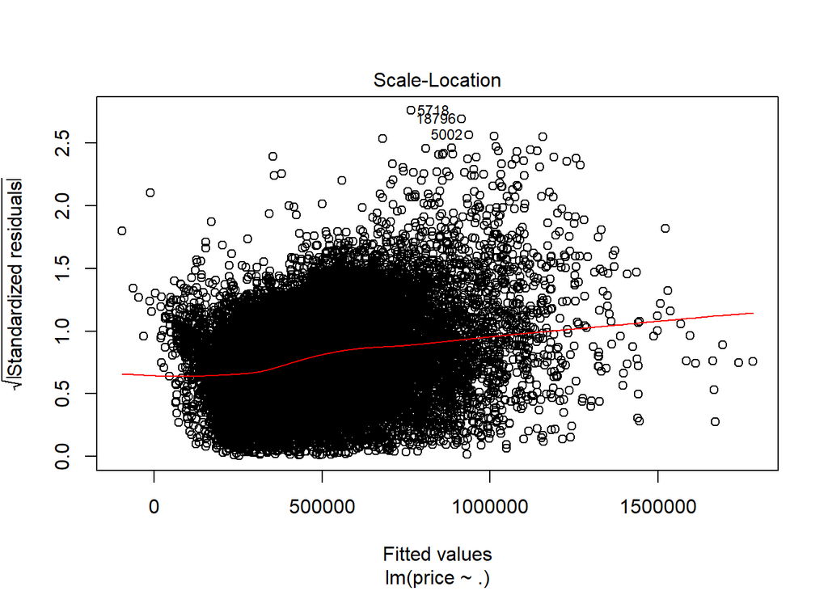

```r
plot(fit,3)
```

we see here that we have some degree of heteroscedasticity

checking the normality

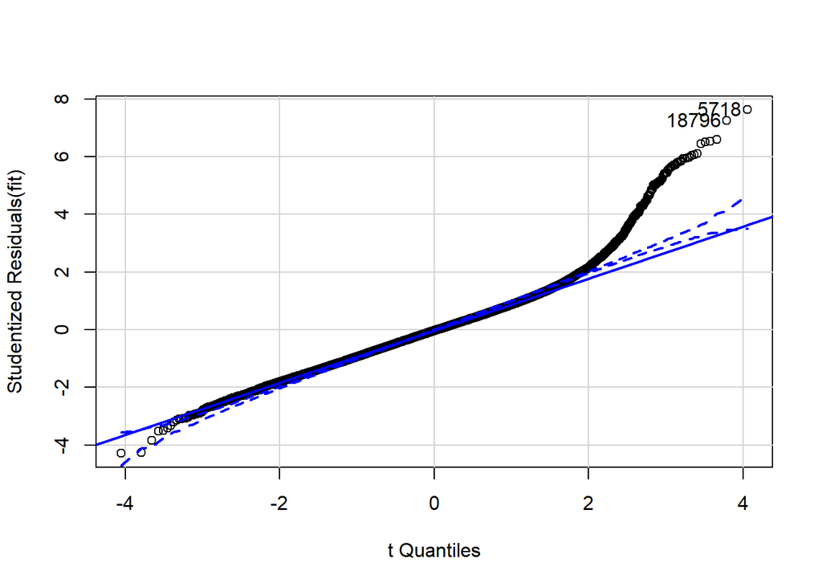

```
## [1]  5718 18796
```

```r
qqPlot(fit)
```

OK , the qqplot shows that the data has a degree of skewness

and to prove it lets see histogram

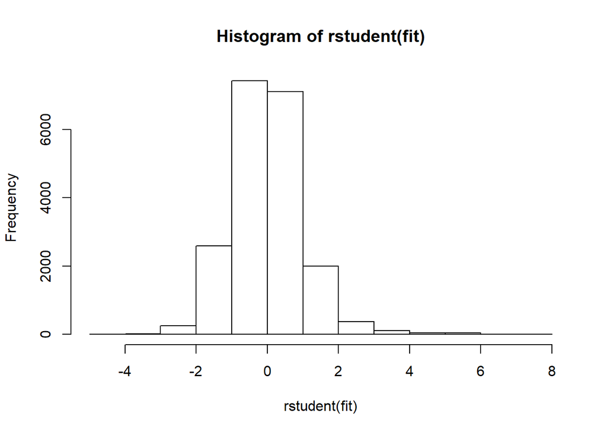

```r
hist(rstudent(fit))
```

some right skew but the data still good

the only issue we have to handle is heteroscedasticity

now i will check partial residual to know the problematic variable

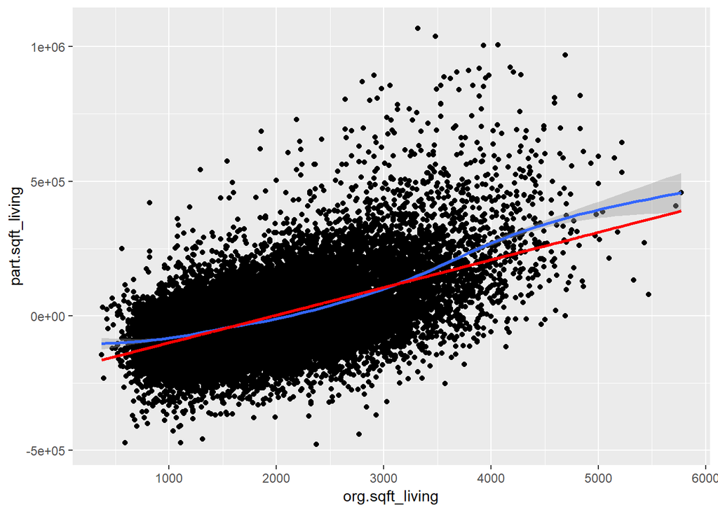

```r
resid<-resid(fit)
term<-predict(fit,houses,type = "terms")%>%data.frame()

partial.resid<-resid+term
houses.org<-houses
names(houses.org)<-paste("org",names(houses),sep = ".")
names(partial.resid)<-paste("part",names(partial.resid),sep = ".")
names(term)<-paste("term",names(term),sep = ".")
allpartial<-cbind(houses.org[,-1],partial.resid,term)


allpartial%>%ggplot(aes(org.sqft_living,part.sqft_living))+
        geom_point()+
        geom_smooth()+
        geom_line(aes(x = org.sqft_living,y=term.sqft_living),color="red",lwd=1)
```

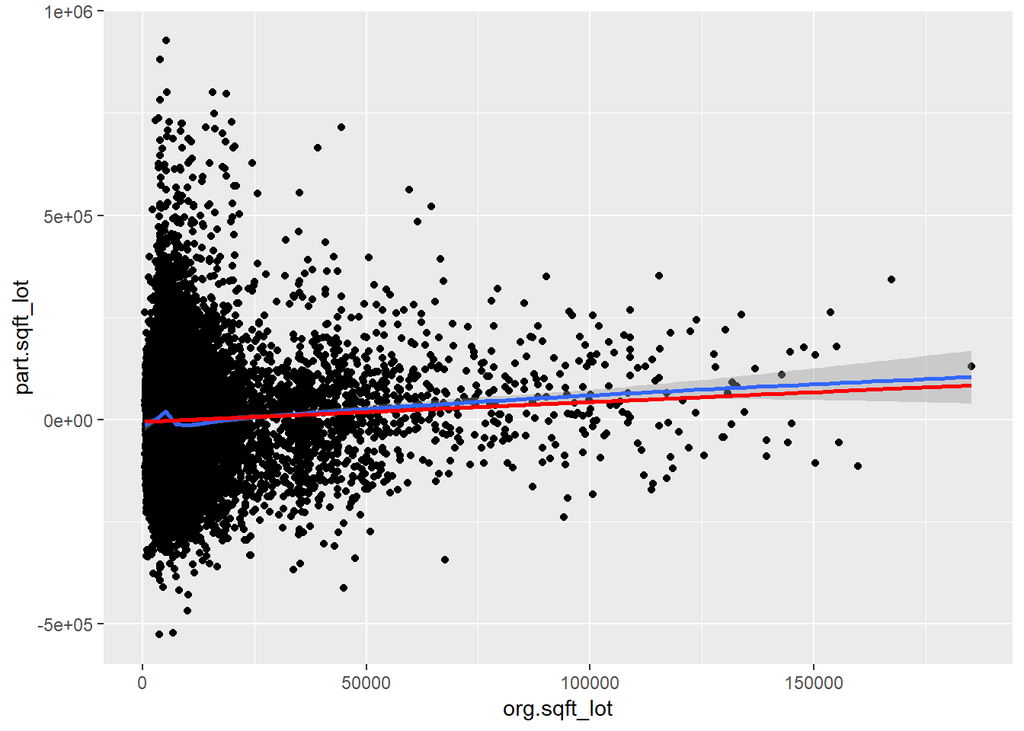

```r
allpartial%>%ggplot(aes(org.sqft_lot,part.sqft_lot))+
        geom_point()+
        geom_smooth()+
        geom_line(aes(x = org.sqft_lot,y=term.sqft_lot),color="red",lwd=1)
```

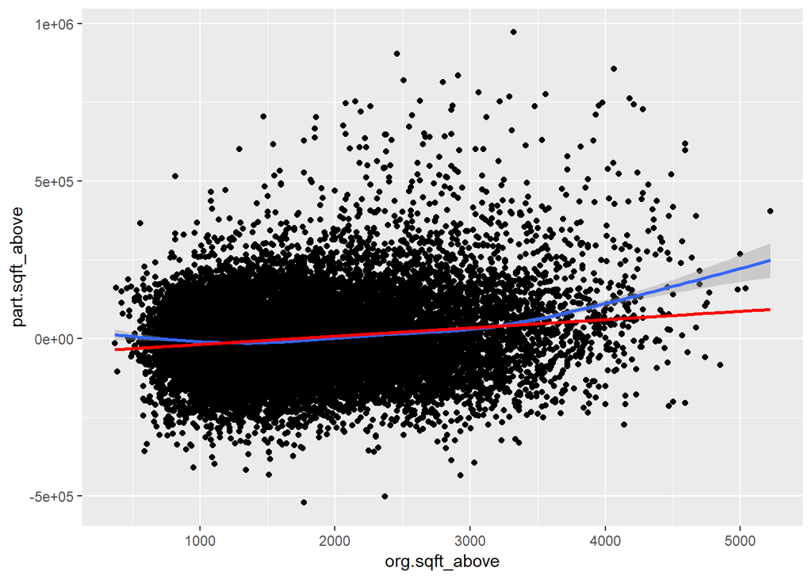

```r
allpartial%>%ggplot(aes(org.sqft_above,part.sqft_above))+
        geom_point()+
        geom_smooth()+
        geom_line(aes(x = org.sqft_above,y=term.sqft_above),color="red",lwd=1)
```

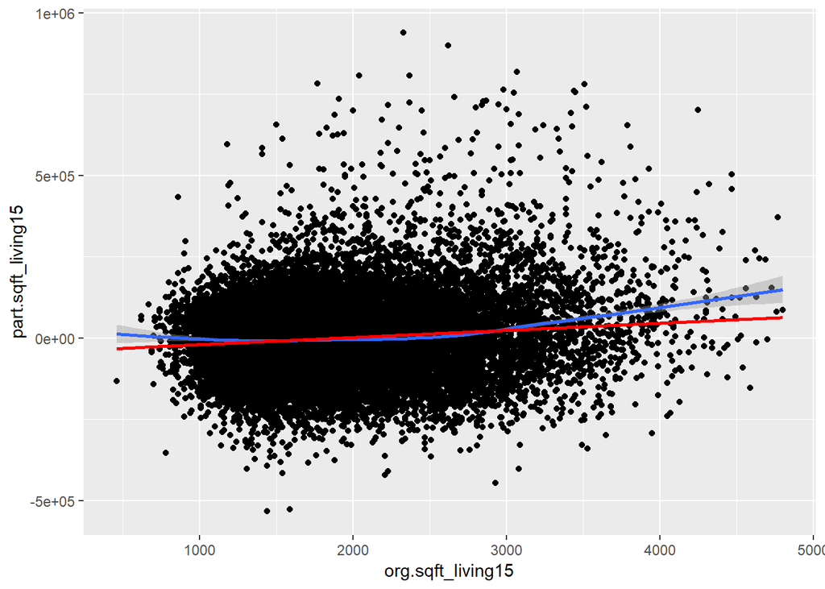

```r
allpartial%>%ggplot(aes(org.sqft_living15,part.sqft_living15))+
        geom_point()+
        geom_smooth()+
        geom_line(aes(x = org.sqft_living15,y=term.sqft_living15),color="red",lwd=1)
```

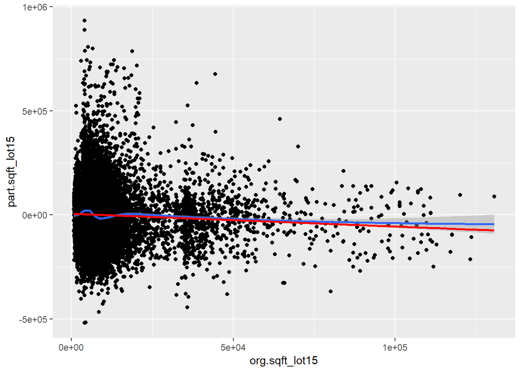

```r
allpartial%>%ggplot(aes(org.sqft_lot15,part.sqft_lot15))+
        geom_point()+
        geom_smooth()+
        geom_line(aes(x = org.sqft_lot15,y=term.sqft_lot15),color="red",lwd=1)
```

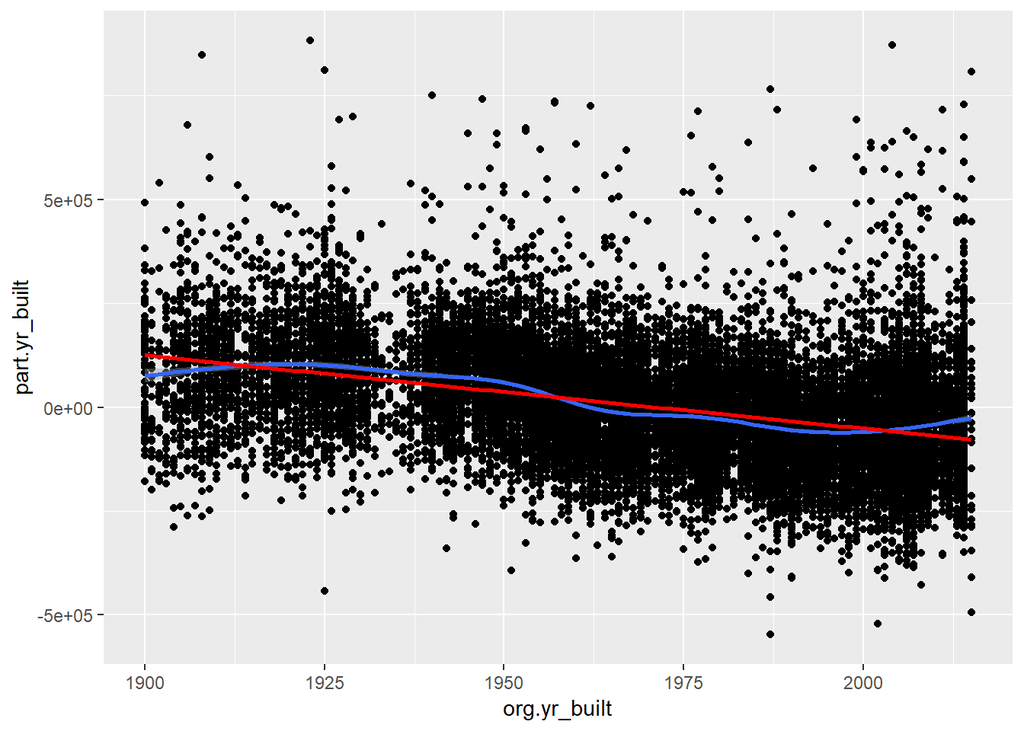

```r
allpartial%>%ggplot(aes(org.yr_built,part.yr_built))+
        geom_point()+
        geom_smooth()+
        geom_line(aes(x = org.yr_built,y=term.yr_built),color="red",lwd=1)
```

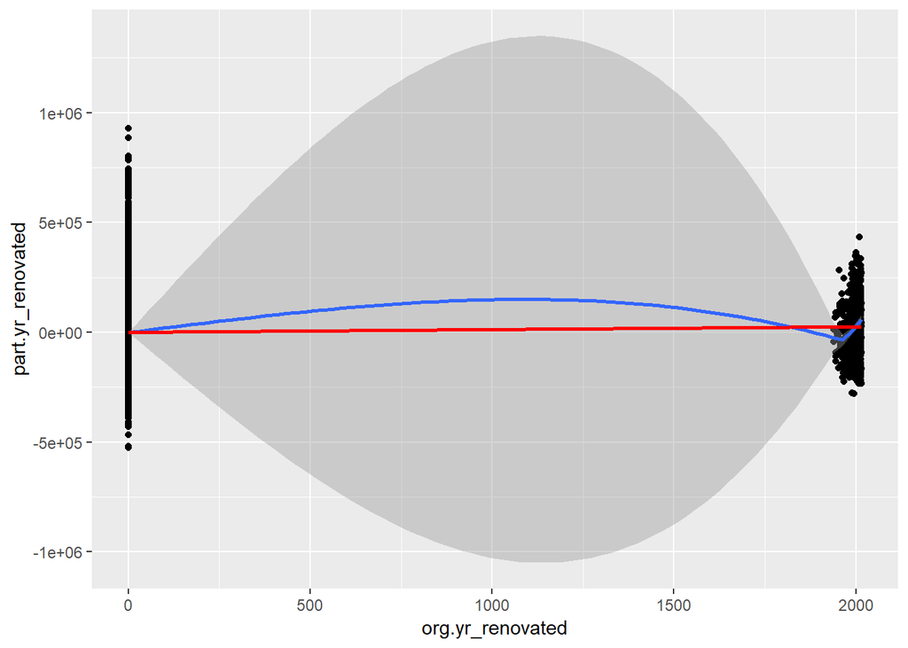

```r
allpartial%>%ggplot(aes(org.yr_renovated,part.yr_renovated))+
        geom_point()+
        geom_smooth()+
        geom_line(aes(x = org.yr_renovated,y=term.yr_renovated),color="red",lwd=1)
```

here we can find that the most problems associated with square foot of lot and the same variable in 2015 and the year of reonivation

i will categorize the renovation years variable into 4 categories according to residuals

```r
houses$yr_renovated%>%table()%>%kable("html")
```

| . | Freq |
| --- | --- |
| 0 | 19281 |
| 1940 | 2 |
| 1944 | 1 |
| 1945 | 3 |
| 1946 | 2 |
| 1948 | 1 |
| 1950 | 2 |
| 1951 | 1 |
| 1953 | 3 |
| 1954 | 1 |
| 1955 | 3 |
| 1956 | 1 |
| 1957 | 3 |
| 1958 | 5 |
| 1959 | 1 |
| 1960 | 3 |
| 1962 | 1 |
| 1963 | 3 |
| 1964 | 5 |
| 1965 | 3 |
| 1967 | 2 |
| 1968 | 6 |
| 1969 | 3 |
| 1970 | 8 |
| 1971 | 2 |
| 1972 | 2 |
| 1973 | 5 |
| 1974 | 3 |
| 1975 | 6 |
| 1976 | 2 |
| 1977 | 7 |
| 1978 | 4 |
| 1979 | 7 |
| 1980 | 9 |
| 1981 | 3 |
| 1982 | 7 |
| 1983 | 14 |
| 1984 | 15 |
| 1985 | 12 |
| 1986 | 8 |
| 1987 | 12 |
| 1988 | 12 |
| 1989 | 17 |
| 1990 | 20 |
| 1991 | 13 |
| 1992 | 12 |
| 1993 | 15 |
| 1994 | 13 |
| 1995 | 13 |
| 1996 | 9 |
| 1997 | 11 |
| 1998 | 13 |
| 1999 | 9 |
| 2000 | 21 |
| 2001 | 15 |
| 2002 | 12 |
| 2003 | 25 |
| 2004 | 20 |
| 2005 | 27 |
| 2006 | 18 |
| 2007 | 26 |
| 2008 | 9 |
| 2009 | 19 |
| 2010 | 15 |
| 2011 | 12 |
| 2012 | 11 |
| 2013 | 28 |
| 2014 | 78 |
| 2015 | 9 |

```r
stdresid<-rstudent(fit)

catigor<-houses%>%mutate(stdresid)%>%
        group_by(yr_renovated)%>%
        summarize(medstd=median(stdresid),cnt=n())%>%
        arrange(medstd)%>%
        mutate(cumcnt=cumsum(cnt),renovC=ntile(cumcnt,4))

catigor%>%kable("markdown")
```

| yr_renovated | medstd | cnt | cumcnt | renovC |
| --- | --- | --- | --- | --- |
| 1967 | -1.3146319 | 2 | 2 | 1 |
| 1976 | -1.1681682 | 2 | 4 | 1 |
| 1963 | -1.1644635 | 3 | 7 | 1 |
| 1969 | -1.1364518 | 3 | 10 | 1 |
| 1964 | -1.1031153 | 5 | 15 | 1 |
| 1970 | -1.0855883 | 8 | 23 | 1 |
| 1996 | -1.0752276 | 9 | 32 | 1 |
| 1953 | -1.0183430 | 3 | 35 | 1 |
| 1945 | -0.9554270 | 3 | 38 | 1 |
| 1960 | -0.8671719 | 3 | 41 | 1 |
| 1959 | -0.6575658 | 1 | 42 | 1 |
| 1950 | -0.6536802 | 2 | 44 | 1 |
| 1978 | -0.5931954 | 4 | 48 | 1 |
| 1982 | -0.5847983 | 7 | 55 | 1 |
| 1973 | -0.5711407 | 5 | 60 | 1 |
| 1971 | -0.5155870 | 2 | 62 | 1 |
| 1981 | -0.4807747 | 3 | 65 | 1 |
| 1957 | -0.4715717 | 3 | 68 | 1 |
| 1995 | -0.4594498 | 13 | 81 | 2 |
| 1983 | -0.4412839 | 14 | 95 | 2 |
| 1977 | -0.4311997 | 7 | 102 | 2 |
| 1984 | -0.4227199 | 15 | 117 | 2 |
| 1997 | -0.4130501 | 11 | 128 | 2 |
| 1968 | -0.4060072 | 6 | 134 | 2 |
| 1974 | -0.3795095 | 3 | 137 | 2 |
| 1946 | -0.3785293 | 2 | 139 | 2 |
| 1940 | -0.3263868 | 2 | 141 | 2 |
| 1994 | -0.3208032 | 13 | 154 | 2 |
| 1993 | -0.2803082 | 15 | 169 | 2 |
| 1988 | -0.2740405 | 12 | 181 | 2 |
| 1948 | -0.2578666 | 1 | 182 | 2 |
| 1991 | -0.2541159 | 13 | 195 | 2 |
| 1992 | -0.2498357 | 12 | 207 | 2 |
| 1989 | -0.2221852 | 17 | 224 | 2 |
| 1958 | -0.2079038 | 5 | 229 | 2 |
| 2001 | -0.2000301 | 15 | 244 | 3 |
| 1987 | -0.1873965 | 12 | 256 | 3 |
| 2000 | -0.1789553 | 21 | 277 | 3 |
| 1990 | -0.1543012 | 20 | 297 | 3 |
| 1980 | -0.1477219 | 9 | 306 | 3 |
| 1972 | -0.1006371 | 2 | 308 | 3 |
| 1965 | -0.0930242 | 3 | 311 | 3 |
| 2013 | -0.0892279 | 28 | 339 | 3 |
| 1955 | -0.0803034 | 3 | 342 | 3 |
| 1986 | -0.0612799 | 8 | 350 | 3 |
| 2012 | -0.0611215 | 11 | 361 | 3 |
| 1985 | -0.0536939 | 12 | 373 | 3 |
| 0 | -0.0324502 | 19281 | 19654 | 3 |
| 1975 | 0.0167476 | 6 | 19660 | 3 |
| 2015 | 0.0227493 | 9 | 19669 | 3 |
| 2009 | 0.0288613 | 19 | 19688 | 3 |
| 2011 | 0.0822008 | 12 | 19700 | 3 |
| 1998 | 0.0945444 | 13 | 19713 | 4 |
| 2007 | 0.1200742 | 26 | 19739 | 4 |
| 1979 | 0.1245174 | 7 | 19746 | 4 |
| 2004 | 0.2679457 | 20 | 19766 | 4 |
| 2006 | 0.2908748 | 18 | 19784 | 4 |
| 2003 | 0.2965783 | 25 | 19809 | 4 |
| 1944 | 0.3629567 | 1 | 19810 | 4 |
| 1951 | 0.4672665 | 1 | 19811 | 4 |
| 2014 | 0.4996164 | 78 | 19889 | 4 |
| 2005 | 0.5223866 | 27 | 19916 | 4 |
| 2010 | 0.5686400 | 15 | 19931 | 4 |
| 2002 | 0.6547362 | 12 | 19943 | 4 |
| 1956 | 0.8582450 | 1 | 19944 | 4 |
| 1999 | 0.9077240 | 9 | 19953 | 4 |
| 2008 | 1.0379758 | 9 | 19962 | 4 |
| 1962 | 1.2237277 | 1 | 19963 | 4 |
| 1954 | 2.1236397 | 1 | 19964 | 4 |

```r
catigor<-catigor%>%select(yr_renovated,renovC)


houses<-(houses)%>%left_join(catigor)%>%mutate(renovC=factor(renovC))
houses<-houses%>%select(-yr_renovated)

houses%>%head%>%kable("markdown")
```

| price | bedrooms | bathrooms | sqft_living | sqft_lot | floors | waterfront | view | condition | grade | sqft_above | yr_built | sqft_living15 | sqft_lot15 | group | renovC |
| --- | --- | --- | --- | --- | --- | --- | --- | --- | --- | --- | --- | --- | --- | --- | --- |
| 221900 | 3 | 1.00 | 1180 | 5650 | 1 | 0 | 0 | 3 | 7 | 1180 | 1955 | 1340 | 5650 | 5 | 3 |
| 538000 | 3 | 2.25 | 2570 | 7242 | 2 | 0 | 0 | 3 | 7 | 2170 | 1951 | 1690 | 7639 | 4 | 2 |
| 180000 | 2 | 1.00 | 770 | 10000 | 1 | 0 | 0 | 3 | 6 | 770 | 1933 | 2720 | 8062 | 4 | 3 |
| 604000 | 4 | 3.00 | 1960 | 5000 | 1 | 0 | 0 | 5 | 7 | 1050 | 1965 | 1360 | 5000 | 4 | 3 |
| 510000 | 3 | 2.00 | 1680 | 8080 | 1 | 0 | 0 | 3 | 8 | 1680 | 1987 | 1800 | 7503 | 4 | 3 |
| 257500 | 3 | 2.25 | 1715 | 6819 | 2 | 0 | 0 | 3 | 7 | 1715 | 1995 | 2238 | 6819 | 5 | 3 |

```r
table(houses$renovC)
```

```
##
##     1     2     3     4
##    68   161 19471   264
```

recalculating the fit

```r
fit<-houses%>%with(lm(price~.,data=houses))
summary(fit)
```

```
##
## Call:
## lm(formula = price ~ ., data = houses)
##
## Residuals:
##     Min      1Q  Median      3Q     Max
## -523310  -77900   -4030   67725  930210
##
## Coefficients:
##                 Estimate Std. Error t value Pr(>|t|)
## (Intercept)    3.239e+06  8.498e+04  38.117  < 2e-16 ***
## bedrooms      -1.986e+04  1.332e+03 -14.911  < 2e-16 ***
## bathrooms      2.627e+04  2.226e+03  11.801  < 2e-16 ***
## sqft_living    1.028e+02  3.123e+00  32.907  < 2e-16 ***
## sqft_lot       4.764e-01  1.227e-01   3.884 0.000103 ***
## floors         5.000e+03  2.358e+03   2.120 0.034018 *
## waterfront1    5.332e+05  3.522e+04  15.140  < 2e-16 ***
## view3          1.200e+05  7.211e+03  16.637  < 2e-16 ***
## view4          3.492e+05  1.559e+04  22.398  < 2e-16 ***
## view2          6.184e+04  4.657e+03  13.277  < 2e-16 ***
## view1          1.023e+05  8.615e+03  11.877  < 2e-16 ***
## condition.L    5.938e+04  3.481e+04   1.706 0.088056 .
## condition.Q   -5.216e+02  2.942e+04  -0.018 0.985853
## condition.C    1.148e+04  1.881e+04   0.611 0.541475
## condition^4    3.053e+03  8.662e+03   0.352 0.724501
## grade          7.469e+04  1.426e+03  52.397  < 2e-16 ***
## sqft_above     2.671e+01  2.949e+00   9.056  < 2e-16 ***
## yr_built      -1.772e+03  4.501e+01 -39.360  < 2e-16 ***
## sqft_living15  2.181e+01  2.417e+00   9.024  < 2e-16 ***
## sqft_lot15    -5.939e-01  1.503e-01  -3.950 7.83e-05 ***
## group2        -1.367e+05  2.925e+03 -46.718  < 2e-16 ***
## group3        -2.332e+05  3.136e+03 -74.364  < 2e-16 ***
## group4        -2.107e+05  3.092e+03 -68.141  < 2e-16 ***
## group5        -3.184e+05  3.328e+03 -95.665  < 2e-16 ***
## renovC2        6.885e+04  1.767e+04   3.897 9.79e-05 ***
## renovC3        6.777e+04  1.493e+04   4.541 5.64e-06 ***
## renovC4        1.366e+05  1.664e+04   8.204 2.46e-16 ***
## ---
## Signif. codes:  0 '***' 0.001 '**' 0.01 '*' 0.05 '.' 0.1 ' ' 1
##
## Residual standard error: 122000 on 19937 degrees of freedom
## Multiple R-squared:  0.7611, Adjusted R-squared:  0.7608
## F-statistic:  2443 on 26 and 19937 DF,  p-value: < 2.2e-16
```

Good , all categories are significant

now lets try the weighted regression and start with calculating the weights

```r
residl<-resid(fit)%>%abs()
fited<-fitted(fit)
residfit<-lm(residl~fited)
fittresid<-fitted(residfit)
wts<-1/fittresid^2

wtsfit<-houses%>%with(lm(price~.,data=houses,weights = wts))
summary(wtsfit)
```

```
##
## Call:
## lm(formula = price ~ ., data = houses, weights = wts)
##
## Weighted Residuals:
##     Min      1Q  Median      3Q     Max
## -4.0657 -0.8911 -0.0765  0.7666 13.6759
##
## Coefficients:
##                 Estimate Std. Error t value Pr(>|t|)
## (Intercept)    2.780e+06  7.615e+04  36.506  < 2e-16 ***
## bedrooms      -1.943e+04  1.158e+03 -16.779  < 2e-16 ***
## bathrooms      1.874e+04  1.974e+03   9.495  < 2e-16 ***
## sqft_living    9.526e+01  2.969e+00  32.083  < 2e-16 ***
## sqft_lot       6.726e-01  1.059e-01   6.349 2.22e-10 ***
## floors         1.150e+04  2.101e+03   5.473 4.47e-08 ***
## waterfront1    5.600e+05  7.409e+04   7.558 4.27e-14 ***
## view3          1.071e+05  8.500e+03  12.597  < 2e-16 ***
## view4          3.550e+05  2.536e+04  13.999  < 2e-16 ***
## view2          5.989e+04  4.929e+03  12.149  < 2e-16 ***
## view1          9.405e+04  9.276e+03  10.140  < 2e-16 ***
## condition.L    8.421e+04  1.866e+04   4.512 6.47e-06 ***
## condition.Q   -1.985e+04  1.577e+04  -1.259 0.208127
## condition.C    1.014e+04  1.036e+04   0.979 0.327814
## condition^4    8.627e+03  5.048e+03   1.709 0.087436 .
## grade          5.794e+04  1.244e+03  46.559  < 2e-16 ***
## sqft_above     1.802e+01  2.819e+00   6.392 1.67e-10 ***
## yr_built      -1.481e+03  4.079e+01 -36.304  < 2e-16 ***
## sqft_living15  3.203e+01  2.260e+00  14.173  < 2e-16 ***
## sqft_lot15    -4.333e-01  1.249e-01  -3.471 0.000520 ***
## group2        -1.205e+05  3.246e+03 -37.123  < 2e-16 ***
## group3        -2.220e+05  3.243e+03 -68.442  < 2e-16 ***
## group4        -1.953e+05  3.262e+03 -59.878  < 2e-16 ***
## group5        -2.901e+05  3.290e+03 -88.173  < 2e-16 ***
## renovC2        5.253e+04  1.454e+04   3.613 0.000304 ***
## renovC3        6.112e+04  1.166e+04   5.244 1.59e-07 ***
## renovC4        1.237e+05  1.393e+04   8.878  < 2e-16 ***
## ---
## Signif. codes:  0 '***' 0.001 '**' 0.01 '*' 0.05 '.' 0.1 ' ' 1
##
## Residual standard error: 1.26 on 19937 degrees of freedom
## Multiple R-squared:  0.7181, Adjusted R-squared:  0.7177
## F-statistic:  1953 on 26 and 19937 DF,  p-value: < 2.2e-16
```

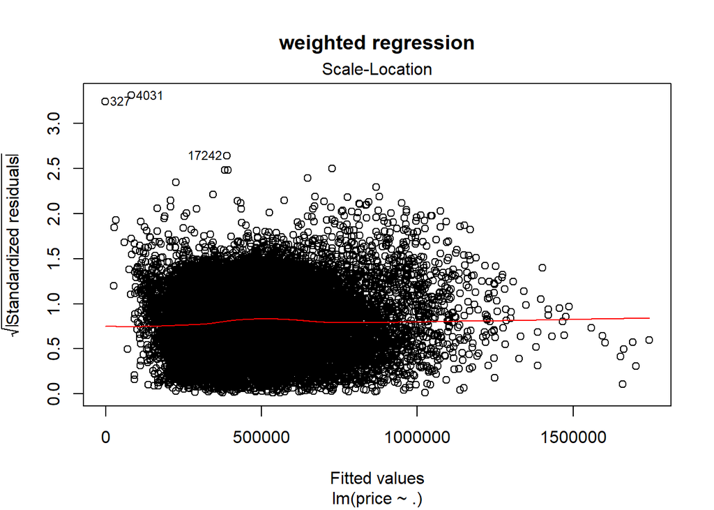

```r
plot(wtsfit,3,main = "weighted regression")
```

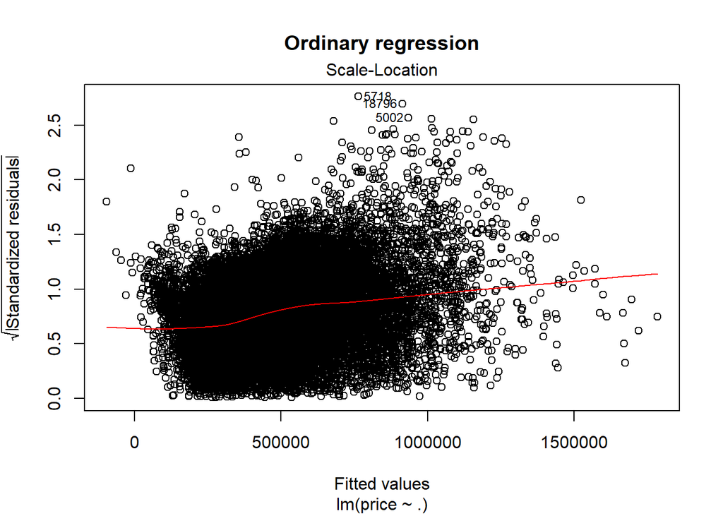

```r
plot(fit,3,main = "Ordinary regression")
```

we see here an improve in the linearity and heteroscedasticity

comparing the standardized coefficients of OLS model and weighted model

```r
data.frame(cbind(lm.beta(fit)$standardized.coefficients,lm.beta(wtsfit)$standardized.coefficients))%>%kable(format = "markdown",digits = 3,col.names = c("Ordinary","Weighted"))
```

|  | Ordinary | Weighted |
| --- | --- | --- |
| (Intercept) | 0.000 | 0.000 |
| bedrooms | -0.068 | -0.067 |
| bathrooms | 0.074 | 0.053 |
| sqft_living | 0.318 | 0.294 |
| sqft_lot | 0.025 | 0.035 |
| floors | 0.011 | 0.026 |
| waterfront1 | 0.057 | 0.059 |
| view3 | 0.059 | 0.053 |
| view4 | 0.085 | 0.086 |
| view2 | 0.047 | 0.046 |
| view1 | 0.041 | 0.038 |
| condition.L | 0.048 | 0.068 |
| condition.Q | -0.001 | -0.023 |
| condition.C | 0.014 | 0.013 |
| condition^4 | 0.006 | 0.018 |
| grade | 0.320 | 0.248 |
| sqft_above | 0.078 | 0.053 |
| yr_built | -0.208 | -0.173 |
| sqft_living15 | 0.055 | 0.081 |
| sqft_lot15 | -0.025 | -0.018 |
| group2 | -0.236 | -0.208 |
| group3 | -0.377 | -0.359 |
| group4 | -0.348 | -0.322 |
| group5 | -0.497 | -0.453 |
| renovC2 | 0.025 | 0.019 |
| renovC3 | 0.042 | 0.038 |
| renovC4 | 0.063 | 0.057 |

The Coefficients are so close to each other

Now lets see the ability of our model to predict out sample data

```r
houses<-cbind(houses,wts)

set.seed(4785)

trainidx<-createDataPartition(y = houses$price,p = .75,list = F)
traindata<-houses[trainidx,]
testdata<-houses[-trainidx,]
```

running the model

```r
set.seed(3454)
trainfit<-traindata%>%with(lm(price~.,data = traindata[,-length(names(traindata))],weights = traindata$wts))
summary(trainfit)
```

```
##
## Call:
## lm(formula = price ~ ., data = traindata[, -length(names(traindata))],
##     weights = traindata$wts)
##
## Weighted Residuals:
##     Min      1Q  Median      3Q     Max
## -4.1019 -0.8939 -0.0758  0.7716 13.7050
##
## Coefficients:
##                 Estimate Std. Error t value Pr(>|t|)
## (Intercept)    2.807e+06  8.800e+04  31.900  < 2e-16 ***
## bedrooms      -1.950e+04  1.336e+03 -14.597  < 2e-16 ***
## bathrooms      1.838e+04  2.272e+03   8.090 6.40e-16 ***
## sqft_living    9.243e+01  3.417e+00  27.049  < 2e-16 ***
## sqft_lot       7.483e-01  1.235e-01   6.059 1.40e-09 ***
## floors         1.257e+04  2.433e+03   5.165 2.43e-07 ***
## waterfront1    5.638e+05  7.454e+04   7.564 4.13e-14 ***
## view3          1.107e+05  9.718e+03  11.394  < 2e-16 ***
## view4          3.500e+05  2.768e+04  12.643  < 2e-16 ***
## view2          6.173e+04  5.685e+03  10.859  < 2e-16 ***
## view1          9.688e+04  1.020e+04   9.502  < 2e-16 ***
## condition.L    9.235e+04  2.330e+04   3.964 7.41e-05 ***
## condition.Q   -2.660e+04  1.968e+04  -1.352  0.17643
## condition.C    1.896e+04  1.275e+04   1.487  0.13693
## condition^4    4.314e+03  6.060e+03   0.712  0.47647
## grade          5.897e+04  1.439e+03  40.973  < 2e-16 ***
## sqft_above     2.151e+01  3.234e+00   6.651 3.00e-11 ***
## yr_built      -1.498e+03  4.712e+01 -31.799  < 2e-16 ***
## sqft_living15  3.170e+01  2.624e+00  12.084  < 2e-16 ***
## sqft_lot15    -5.765e-01  1.480e-01  -3.896 9.84e-05 ***
## group2        -1.225e+05  3.767e+03 -32.536  < 2e-16 ***
## group3        -2.252e+05  3.761e+03 -59.880  < 2e-16 ***
## group4        -1.974e+05  3.780e+03 -52.208  < 2e-16 ***
## group5        -2.945e+05  3.816e+03 -77.169  < 2e-16 ***
## renovC2        5.127e+04  1.678e+04   3.055  0.00226 **
## renovC3        6.332e+04  1.342e+04   4.718 2.41e-06 ***
## renovC4        1.256e+05  1.635e+04   7.684 1.64e-14 ***
## ---
## Signif. codes:  0 '***' 0.001 '**' 0.01 '*' 0.05 '.' 0.1 ' ' 1
##
## Residual standard error: 1.259 on 14947 degrees of freedom
## Multiple R-squared:  0.7204, Adjusted R-squared:  0.7199
## F-statistic:  1481 on 26 and 14947 DF,  p-value: < 2.2e-16
```

```r
predicted<-predict(trainfit,testdata)

cbind(RMSE=RMSE(pred = predicted,obs = testdata$price),R2=R2(pred = predicted,obs = testdata$price))%>%kable("markdown")
```

| RMSE | R2 |
| --- | --- |
| 124517.3 | 0.7519751 |